# CIBERlite

Gjalt-Jorn Peters & Rik Crutzen

14:31:26 on 2020-12-03 CET (UTC+0100)

# Introduction

## Status of this file

This is the R Markdown file for the CIBERlite study. This study is a project of the Academy of Behavior Change. The canonical URL for this study is https://ciberlite.com. Initially, this will resolve to the study’s Open Science Framework repository (https://osf.io/2uwxp/), but in time it may point to a website to facilitate CIBERlite implementation by prevention organisations. The study’s OSF repository (repo) synchronises with the GitHub repo at https://github.com/academy-of-behavior-change/ciberlite.

This R Markdown file is very much a living document, and as such, also contains all R code. For the CIBERlite plot, scroll down to the CIBERlite plots heading.

Note that because this is a living project, you will probably need the most up-to-date version of the `userfriendlyscience` package (*if* that has been submitted to CRAN yet). See https://userfriendlyscience.com for instructions as to how to install it.

## Background of the project

CIBERlite is a project where we aim to provide an easy-to-use and apply rudimentary approximation of a determinant study, so that practitioners (e.g. for preventions organisations) can feasibly quickly get an idea of which determinants are the most relevant in predicting a given target behavior in a given target population. To develop this method, we conduct a study comparing relative determinant levels for eight behaviors in the general population.

A second goal of CIBERlite, but only one that only emerged as we were working on this project, is to work towards a framework for calibrating determinant operationalisations over behaviors and populations.

The preregistration form for this study is at https://osf.io/cjz6n/register/565fb3678c5e4a66b5582f67. That is a good place to start before reading further.

## License of these materials

This file and the other materials in the OSF and GitHub repo’s associated with this project are licensed under the Creative Commons attribution share alike license (CC-BY-NC-SA; see http://creativecommons.org/licenses/by-nc-sa/4.0/). This means that you are allowed to copy and distribute these files freely, but you’re not allowed to sell them. It also means that if you create derivative works (i.e. if you remix, transform, or build upon the material), you must distribute your contributions under the same license as the original.

# Setup of R environment

Here, we configure some settings and load the required R packages.

# Data import and merging

This includes sanitizing the private data files for publication.

```r
########################################################################
###
### Import data from Open University survey
###
########################################################################
###
### First delete the data from students who indicated they want their
### data destroyed (note that this private data file is excluded from
### synchronization with the GitHub repository, and therefore the OSF
### repository, using .gitignore)
###
### Note: if you ever accidently commit private data to git, this can
### be removed using bfg, see:
###
###   https://help.github.com/articles/removing-sensitive-data-from-a-repository/
###   https://rtyley.github.io/bfg-repo-cleaner/
###
### For example, assuming you have version 1.13 installed in the
### directory B:\Apps\bfg, and you just cloned a fresh copy using
###
###   git clone --mirror https://github.com/academy-of-behavior-change/ciberlite
###
### Then you can delete all comma separated values (*.csv) files from the
### git history using:
###
###   java -jar B:\Apps\bfg\bfg-1.13.0.jar --delete-files *.csv ciberlite.git
###
### Then run, as instructed by bfg:
###
###   cd ciberlite.git
###   git reflog expire --expire=now --all && git gc --prune=now --aggressive
###   git push
###
########################################################################

### Get a list of all data files in data directory
privateDataFiles <-
  list.files(dataPath);

### Select only those matching the regular expression for
### Open University data files
privateDataFiles <-
  grep(privateOUdataFileRegEx,
       privateDataFiles,
       value=TRUE);

if (length(privateDataFiles) > 0) {
  ### Private data files are present; this means we run on the PC
  ### of one of the researchers. That means we should sanitize the
  ### datasets and prepare them for publishing.

  dataDeletionVarName <- paste0(dataDeletionVarCode,
                              "_",
                              dataDeletionSubQuestionCode);

  ### Loop through the files
  for (currentFilename in privateDataFiles) {

    ### Run within local, temporary namespace (so that all variables
    ### are deleted afterwards)
    local({

      currentScriptName <- sub('data_file_\\[PRIVATE-(.*)\\.csv',
                               'syntax_file_\\[\\1.R',
                               currentFilename);

      scriptfilePath <- file.path(dataPath,
                                  currentScriptName);

      ### Then read the datafile as character vector
      fullPrivateDataFile <-
        readLines(file.path(dataPath,
                            currentFilename));
      ufs::cat0("\n\nRead data file '", currentFilename, "'.\n\n");

      ### Remove lines of participants who don't want their data to be used
      partialPrivateDataFile <-
        gdpR::removeLinesFromRawData(fullPrivateDataFile,
                                     varName=dataDeletionVarName,
                                     varValue=dataDeletionVarValue,
                                     scriptfile=scriptfilePath);

      ### Set all countries except for 1 and 2 to missing
      partialPrivateDataFile <-
        gdpR::removeValuesFromRawData(partialPrivateDataFile,
                                      varName='country',
                                      varValuesToRetain=c(1,2),
                                      scriptfile=scriptfilePath);

      ### Construct new filename to write public version of data to
      newTmpFilename <- sub(privateFileIdentificationString,
                            publicFileIdentificationString,
                            currentFilename,
                            fixed=TRUE);

      ### Store new datafile
      writeLines(partialPrivateDataFile,
                 file.path(dataPath,
                           newTmpFilename));

      ufs::cat0("\n\nStored data file '", newTmpFilename, "'.\n\n");

    });  ### End local namespace

  }
}
```

Read data file ‘survey_675712_R_data_file_[PRIVATE-OU-version2].csv’.

Variable ‘dataMustBeDeleted_delete’ is variable number 86. Deleting these lines because they match regular expression ^(?:“[^"]*",){85}"2":‘4’, ‘13’, ‘17’, ‘21’, ‘22’, ‘27’, ‘28’, ‘47’, ‘63’, ‘67’, ‘73’, ‘76’, ‘89’, ‘93’, ‘99’, ‘107’, ‘110’, ‘116’, ‘125’, ‘133’, ‘135’, ‘143’, ‘147’, ‘149’, ‘150’, ‘152’, ‘162’, ‘166’, ‘184’, ‘186’, ‘189’, ‘195’, ‘202’, ‘211’, ‘214’, ‘218’, ‘229’, ‘230’, ‘234’, ‘238’, ‘242’, ‘265’, ‘266’, ‘275’, ‘284’, ‘285’, ‘287’, ‘294’, ‘308’, ‘314’, ‘315’, ‘336’ & ‘338’. Deleting 53 out of 346 lines (result: 293 lines). Variable ‘country’ is variable number 83. Repacing matches in these lines because they match regular expression ^((?:"[^"]*”,){82})“(?:(?!12[^"]+)”(.*)$ (setting them to \1""\2):‘1’, ‘28’, ‘71’, ‘92’, ‘96’, ‘106’, ‘125’, ‘169’, ‘186’, ‘214’ & ‘290’.

Stored data file ‘survey_675712_R_data_file_[PUBLIC-OU-version2].csv’.

Read data file ‘survey_722821_R_data_file_[PRIVATE-OU-version].csv’.

Variable ‘dataMustBeDeleted_delete’ is variable number 76. Deleting these lines because they match regular expression ^(?:"[^"]*“,){75}”2":‘3’, ‘10’, ‘15’, ‘17’, ‘22’, ‘33’, ‘45’, ‘47’, ‘55’, ‘56’, ‘58’, ‘64’, ‘65’, ‘75’, ‘81’, ‘82’, ‘83’, ‘87’, ‘89’, ‘93’, ‘100’, ‘104’, ‘106’, ‘111’, ‘114’, ‘125’, ‘126’, ‘128’, ‘132’, ‘133’, ‘134’, ‘141’, ‘152’, ‘160’, ‘165’, ‘168’, ‘170’, ‘177’, ‘178’, ‘179’, ‘182’, ‘188’, ‘191’, ‘194’, ‘198’, ‘210’, ‘216’, ‘231’, ‘240’, ‘241’, ‘249’, ‘255’, ‘256’, ‘257’, ‘259’, ‘260’, ‘261’, ‘265’, ‘268’, ‘269’, ‘270’, ‘271’ & ‘275’. Deleting 63 out of 279 lines (result: 216 lines). Variable ‘country’ does not occur in the script file; not processing any further.

Stored data file ‘survey_722821_R_data_file_[PUBLIC-OU-version].csv’.

```r
########################################################################
### Import data from Open University survey
########################################################################

publicDataFiles <-
  list.files(dataPath);

### Select only those matching the regular expression for
### public Open University data files
publicDataFiles <-
  grep(publicOUdataFileRegEx,
       publicDataFiles,
       value=TRUE);

if (length(publicDataFiles) > 0) {
  ### Public data files are present, so read them.
  dat_ou.raw.separate <- list();
  ### Loop through the files
  for (currentFilename in publicDataFiles) {
      ### Derive name of script file to import data
      currentScriptName <- sub('data_file_\\[PUBLIC-(.*)\\.csv',
                               'syntax_file_\\[\\1.R',
                               currentFilename);
      ### Import data
      dat_ou.raw.separate[[currentFilename]] <-
        limonaid::ls_import_data(
          datafile = file.path(dataPath,
                               currentFilename),
          datafileRegEx = privateOUdataFileRegEx,
          scriptfile = file.path(dataPath,
                                 currentScriptName),
          categoricalQuestions = categoricalQuestions
        );
  }
  ### Merge datafiles
  dat_ou.raw <- do.call(plyr::rbind.fill,
                        dat_ou.raw.separate);
}

### Verify that no entries were read where people indicated they wanted
### their data removed
if (any(dat_ou.raw[, dataDeletionVarName]==dataDeletionVarValue, na.rm=TRUE)) {
  stop("The public data contains data from people who indicated they ",
       "wanted their data to be removed!");
} else {
  ### Delete variable storing whether people want their data deleted,
  ### so that the data can be easily merged with the dataset from
  ### ondrzk.nl
  dat_ou.raw[, grepl(dataDeletionVarCode,
                     names(dat_ou.raw))] <- NULL;
}

########################################################################
### Import data from separate online survey
########################################################################

dat_ondrzk.raw <-
  limonaid::ls_import_data(
    dataPath = dataPath,
    datafileRegEx = ondrzkDataFileRegEx,
    scriptfile = file.path(dataPath,
                           ondrzkDataLoadScriptName),
    categoricalQuestions = categoricalQuestions
  );

########################################################################
### Paper-and-pencil survey
########################################################################

### Save first two lines of 'onderzk' data as example for
### data entry of paper-and-pencil questionnaires
dataEntryTemplateFile <-
  file.path(processedDataPath,
            "data-entry-template.ods");
if (file.exists(dataEntryTemplateFile)) {
  unlink(dataEntryTemplateFile)
}
readODS::write_ods(dat_ondrzk.raw[1:2, 7:75],
                   dataEntryTemplateFile);
########################################################################
### Read the data that was entered from the paper-and-pencil survey
########################################################################

dataEntryFile <-
  file.path(processedDataPath,
            "data-entry-template--data-entered.ods");
dat_paperPencil <-
  readODS::read_ods(dataEntryFile);

########################################################################
### Data merging and aggregations
########################################################################

### Because these are different versions of LimeSurvey, the timing
### variables are named differently, so make these consistent
names(dat_ou.raw) <- sub("Vraag\\.?tijd\\.\\.",
                         "questionTime_",
                         names(dat_ou.raw));
names(dat_ou.raw) <- sub("Groep\\.?tijd\\.\\.",
                         "groupTime_",
                         names(dat_ou.raw));
names(dat_ondrzk.raw) <- sub("Vraag\\.?tijd\\.\\.",
                             "questionTime_",
                             names(dat_ondrzk.raw));
names(dat_ondrzk.raw) <- sub("Groep\\.?tijd\\.\\.",
                             "groupTime_",
                             names(dat_ondrzk.raw));

### Merge online data files
dat <- plyr::rbind.fill(dat_ou.raw, dat_ondrzk.raw);

### We do not merge with the paper and pencil data file;
### this contains only a few participants, and in additon,
### contains different coding for the variables.
#dat <- rbind.fill(dat, dat_paperPencil);

### Add urbanisation using first two numbers of postcode
dat <- merge(dat,
             pcDat[, c('postcode', 'urbanisation')],
             by.x="region",
             by.y="postcode",
             all.x = TRUE,
             all.y = FALSE);

### Set to missing for participants from another country than the Netherlands
dat$urbanisation[dat$country != "Nederland"] <- NA;

### Export merged datafile
write.csv(dat,
          file.path(processedDataPath,
                    "ciberlite-data--merged-public-raw.csv"));
```

# CIBERlite function definition

Note that this function, when done, will be integrated into the userfriendlyscience package.

```r
### Add variables names of the determinants' measures and compute
### means where necessary
for (i in seq_along(detStruct)) {
  behaviorchange::detStructAddVarNames(detStruct[[i]], names(dat));
  dat <- behaviorchange::detStructComputeScales(detStruct[[i]], dat);
}

### View means
# lapply(dat[, grepl('attitude', names(dat))], mean, na.rm=TRUE);
# lapply(dat[, grepl('perceivedNorm', names(dat))], mean, na.rm=TRUE);
# lapply(dat[, grepl('perceivedBehavioralControl', names(dat))], mean, na.rm=TRUE);

CIBERlite <- function(data,
                      determinants,
                      targets,
                      determinantOrder = NULL,
                      determinantLabels = NULL,
                      subDeterminantLabels = NULL,
                      title=NULL,
                      conf.level = list(means = 0.9999,
                                        associations = 0.95),
                      scaleRange = NULL,
                      determinantAesthetics = list(fill = 'black',
                                                   color=NA,
                                                   alpha=.5),
                      subDeterminantAesthetics = list(fill = 'black',
                                                      color=NA,
                                                      alpha=.5),
                      rDiamondAesthetics = list(fill = '#c4c4c4',
                                                color=NA,
                                                alpha=.75)) {

  if (is.list(determinants)) {
    subDeterminantNames <- unlist(determinants);
    determinantNames <- names(determinants);
  } else {
    subDeterminantNames <- c();
    determinantNames <- determinants;
  }
  if (is.null(determinantOrder)) {
    determinantOrder <- seq_along(determinantNames);
  }

  if (getOption('ufs.debug', FALSE)) {
    cat("\n", repStr("-", 50), "\n");
    print(targets);
    print(determinantNames);
    print(subDeterminantNames);
  }

  ### Select relevant rows from dataset
  dat <- data[, c(targets, determinantNames, subDeterminantNames)];

  ### Set minimum and maximum for the used scales, if not provided
  if (is.null(scaleRange)) {
    scaleRange <- c(min(dat[, c(determinantNames, subDeterminantNames)], na.rm=TRUE),
                    max(dat[, c(determinantNames, subDeterminantNames)], na.rm=TRUE));
  }

  if (getOption('ufs.debug', FALSE)) {
    cat("\n", repStr("-", 50), "\n");
    print(determinantOrder);
    print(scaleRange);
  }

  # print(dim(is.na(dat[, c(determinantNames, subDeterminantNames)])));
  # print((scaleRange[2] - scaleRange[1]));
  # print(class(dim(((dat[, c(determinantNames, subDeterminantNames)] - scaleRange[1]) /
  #             (scaleRange[2] - scaleRange[1])))));

  ### Translate subdeterminants and determinants to 0-1 range
  dat[, c(determinantNames, subDeterminantNames)] <-
    ((dat[, c(determinantNames, subDeterminantNames)] - scaleRange[1]) /
              (scaleRange[2] - scaleRange[1]));

  if (is.list(determinants)) {
    ### We also have subdeterminants, so also get the means for those.

    subDeterminantDat <-
      as.data.frame(t(
        sapply(
          dat[, subDeterminantNames],
          function(x) {
            return(c(mean = mean(x, na.rm=TRUE),
                     sd = sd(x, na.rm=TRUE)));
            }
          )
        ));
    subDeterminantDat$subdeterminant <- row.names(subDeterminantDat);
    subDeterminantDat$determinant <- rep(determinantNames,
                                         sapply(determinants, length));
    subDeterminantDat$xPos <- rep(determinantOrder,
                                  sapply(determinants, length));
  }

  determinantDat <-
    as.data.frame(t(
      sapply(dat[, determinantNames],
             function(x) {
               return(c(mean = mean(x, na.rm=TRUE),
                        sd = sd(x, na.rm=TRUE)));
               })
    ));
  determinantDat$determinant <- row.names(determinantDat);
  determinantDat$xPos <- determinantOrder;

  determinantTargetCorObject <-
    ufs::associationMatrix(dat,
                           x = determinantNames,
                           y = targets);

  determinantTarget.r <-
    determinantTargetCorObject$output$raw$es;
  determinantTarget.ci.lo <-
    determinantTargetCorObject$output$raw$ci.lo;
  determinantTarget.ci.hi <-
    determinantTargetCorObject$output$raw$ci.hi;

  rDiamondCoordinates <-
    lapply(1:length(targets), function(targetIndex) {
      tmpDf <- cbind(determinantTargetCorObject$output$raw$ci.lo[, targetIndex],
                                       determinantTargetCorObject$output$raw$es[, targetIndex],
                                       determinantTargetCorObject$output$raw$ci.hi[, targetIndex]);
      return(
        lapply(
          1:nrow(tmpDf),
          function(determinantIndex) {
            return(
              ufs::diamondCoordinates(
                tmpDf[determinantIndex, ],
                otherAxisValue = determinantIndex)
              );
            }
          )
        );
     });

  rDiamondLayer <-
    lapply(1:length(targets), function(targetIndex) {
      tmpDf <-
        as.data.frame(
          cbind(determinantTargetCorObject$output$raw$ci.lo[, targetIndex],
                determinantTargetCorObject$output$raw$es[, targetIndex],
                determinantTargetCorObject$output$raw$ci.hi[, targetIndex])
        );
      return(ufs::ggDiamondLayer(tmpDf,
                                 direction="vertical",
                                 color=rDiamondAesthetics$fill,
                                 lineColor=rDiamondAesthetics$color,
                                 alpha=rDiamondAesthetics$alpha));
     });

  if (getOption('ufs.debug', FALSE)) {
    cat("\n", repStr("-", 50), "\n");
    print(determinantDat);
    cat("\n", repStr("-", 50), "\n");
    print(subDeterminantDat);
    cat("\n", repStr("-", 50), "\n");
    print(rDiamondCoordinates);
    cat("\n", repStr("-", 50), "\n");
  }

  if (is.null(determinantLabels)) {
    determinantLabels <- determinantNames;
  }
  if (is.null(subDeterminantLabels)) {
    subDeterminantLabels <- subDeterminantNames;
  }

  ggplot2::ggplot() +
    ggplot2::geom_hline(yintercept = c(0, 1),
                        color="black") +
    ggplot2::geom_bar(data = subDeterminantDat,
                      ggplot2::aes_string(x = 'xPos',
                                          y = 'mean',
                                          group = 'subdeterminant'),
                      stat='identity',
                      position='dodge',
                      fill=subDeterminantAesthetics$fill,
                      color=subDeterminantAesthetics$color,
                      alpha=subDeterminantAesthetics$alpha) +
    ggplot2::geom_bar(data = determinantDat,
                      ggplot2::aes_string(x = 'xPos',
                                          y = 'mean'),
                      stat='identity',
                      position='identity',
                      fill=determinantAesthetics$fill,
                      color=determinantAesthetics$color,
                      alpha=determinantAesthetics$alpha) +
    rDiamondLayer +
    ggplot2::theme_minimal() +
    ggplot2::coord_cartesian(ylim=c(0,1)) +
    ggplot2::scale_x_continuous(
      breaks=determinantOrder,
      labels=determinantLabels,
      sec.axis=ggplot2::dup_axis(
        breaks=c(determinantOrder-.25,
                 determinantOrder+.25),
        labels=c(subDeterminantLabels[ufs::is.odd(seq_along(subDeterminantLabels))],
                 subDeterminantLabels[ufs::is.even(seq_along(subDeterminantLabels))]))) +
    ggplot2::ggtitle(title) +
    ggplot2::xlab(NULL) +
    ggplot2::ylab(NULL);
}
```

# Sample description

The dataset (after sanitization) has 514 rows. 421 rows submitted the complete survey (i.e. have a non-missing value for `submitdate`). Note that providing demographic data was optional, so less data may be available for the demographic variables (age, sex, education, country, and region). We also registered the first two numbers of each participant’s postcode. For Dutch participants, these were used to compute whether they lived in a rural or urban area.

```r
dat$sex_cat <- factor(dat$sex);
dat$edu_cat <- factor(dat$education);
dat$duration_minutes <- dat$Totaaltijd/60;

rosetta::descr(
  dat,
  items = c(
    'age',
    'sex_cat',
    'edu_cat',
    'country',
    'urbanisation',
    'duration_minutes'
  )
);
```

### Descriptives for variables in data frame dat

|  | mean | meanCI | median | mode | var | sd | iqr | se | min | q1 | q3 | max | skewness | kurtosis | dip | totalN | missingN | validN |
| --- | --- | --- | --- | --- | --- | --- | --- | --- | --- | --- | --- | --- | --- | --- | --- | --- | --- | --- |
| age | 35.78 | [34.7; 36.85] | 35.00 | 24 | 124.52 | 11.16 | 17.00 | 0.55 | 17 | 27.00 | 44.00 | 76.00 | 0.41 | -0.33 | 0.02 | 514 | 99 | 415 |
| duration_minutes | 7.04 | [6.36; 7.73] | 5.91 | (Other) | 61.92 | 7.87 | 4.13 | 0.35 | 0 | 4.02 | 8.15 | 110.36 | 6.11 | 64.20 | 0.06 | 514 | 9 | 505 |

#### Frequencies for sex_cat

|  | Frequencies | Perc.Total | Perc.Valid | Cumulative |
| --- | --- | --- | --- | --- |
| Vrouw | 327 | 63.6 | 78.8 | 78.8 |
| Man | 88 | 17.1 | 21.2 | 100.0 |
| Total valid | 415 | 80.7 | 100.0 |  |
| NA (missing) | 99 | 19.3 |  |  |
| Total | 514 | 100.0 |  |  |

#### Frequencies for edu_cat

|  | Frequencies | Perc.Total | Perc.Valid | Cumulative |
| --- | --- | --- | --- | --- |
| VMBO (bijvoorbeeld praktijkonderwijs) | 1 | 0.2 | 0.2 | 0.2 |
| HAVO / VWO | 37 | 7.2 | 9.2 | 9.5 |
| MBO (bijvoorbeeld een ROC) | 8 | 1.6 | 2.0 | 11.5 |
| HBO | 183 | 35.6 | 45.8 | 57.2 |
| WO (bijvoorbeeld een MSc of PhD) | 171 | 33.3 | 42.8 | 100.0 |
| Total valid | 400 | 77.8 | 100.0 |  |
| NA (missing) | 114 | 22.2 |  |  |
| Total | 514 | 100.0 |  |  |

#### Frequencies for country

|  | Frequencies | Perc.Total | Perc.Valid | Cumulative |
| --- | --- | --- | --- | --- |
| Nederland | 207 | 40.3 | 92 | 92 |
| België | 18 | 3.5 | 8 | 100 |
| Total valid | 225 | 43.8 | 100 |  |
| NA (missing) | 289 | 56.2 |  |  |
| Total | 514 | 100.0 |  |  |

#### Frequencies for urbanisation

|  | Frequencies | Perc.Total | Perc.Valid | Cumulative |
| --- | --- | --- | --- | --- |
| Very rural | 11 | 2.1 | 2.8 | 2.8 |
| Rural | 79 | 15.4 | 20.3 | 23.1 |
| Urban | 84 | 16.3 | 21.6 | 44.7 |
| Very urban | 125 | 24.3 | 32.1 | 76.9 |
| Extremely urban | 90 | 17.5 | 23.1 | 100.0 |
| Total valid | 389 | 75.7 | 100.0 |  |
| NA (missing) | 125 | 24.3 |  |  |
| Total | 514 | 100.0 |  |  |

# Analyses

## CIBERlite plots

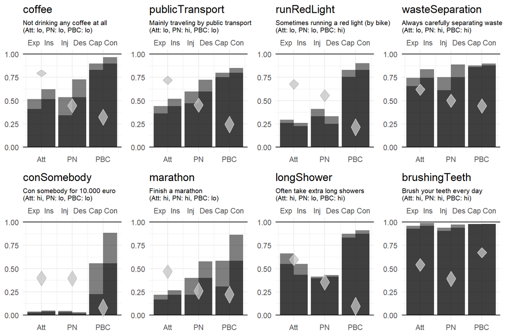

Figure 1: a CIBERlite plot. Note that in their operationalitions, all these behaviors related to the next month (… for the next month, … in the next month, etc).  
Att = Attitude, PN = Perceived Norm, PBC = Perceived Behavioral Control, Exp = Experiential Attitude, Ins = Instrumental Attitude, Inj = Injunctive Norm, Des = Descriptive Norm, Cap = Capacity, Con = Control.

```r
### Set plot titles by adding expectations regarding determinant values
plotSubTitles <- c(coffee = "Not drinking any coffee at all\n(Att: lo, PN: lo, PBC: lo)",
                   publicTransport = "Mainly traveling by public transport\n(Att: lo, PN: hi, PBC: lo)",
                   runRedLight = "Sometimes running a red light (by bike)\n(Att: lo, PN: lo, PBC: hi)",
                   wasteSeparation = "Always carefully separating waste\n(Att: lo, PN: hi, PBC: hi)",
                   conSomebody = "Con somebody for 10.000 euro\n(Att: hi, PN: lo, PBC: lo)",
                   marathon = "Finish a marathon\n(Att: hi, PN: hi, PBC: lo)",
                   longShower = "Often take extra long showers\n(Att: hi, PN: lo, PBC: hi)",
                   brushingTeeth = "Brush your teeth every day\n(Att: hi, PN: hi, PBC: hi)");

CIBERlitePlots <- lapply(seq_along(detStruct),
                         function(i) {
                           behaviorName <- detStruct[[i]]$behaviorRegEx;
                           detStructVars <-
                             detStruct[[i]]$Get('varNames', filterFun=data.tree::isLeaf);
                           ### Set name to variable name of overarching determinant
                           names(detStructVars) <-
                             detStruct[[i]]$Get("scaleVarName", filterFun=data.tree::isLeaf);
                           return(CIBERlite(dat,
                                            determinants=detStructVars,
                                            determinantLabels=c('Att', 'PN', 'PBC'),
                                            subDeterminantLabels=c("Exp", "Ins", "Inj", "Des", "Cap", "Con"),
                                            scaleRange=c(1,5),
                                            targets=detStruct[[i]]$intention$scaleVarName) +
                                    ggplot2::ggtitle(behaviorName,
                                                     subtitle = plotSubTitles[behaviorName]) +
                                    ggplot2::theme(plot.subtitle=ggplot2::element_text(size=8)));
                         });

combinedCIBERlitePlot <- gridExtra::arrangeGrob(grobs=CIBERlitePlots, ncol=4);

ufs::knitFig(
  combinedCIBERlitePlot,
  figWidth=21/2.54,
  figHeight=14/2.54,
  figCaption="Figure 1: a CIBERlite plot. Note that in their operationalitions, all these behaviors related to the next month (... for the next month, ... in the next month, etc).<br />Att = Attitude, PN = Perceived Norm, PBC = Perceived Behavioral Control, Exp = Experiential Attitude, Ins = Instrumental Attitude, Inj = Injunctive Norm, Des = Descriptive Norm, Cap = Capacity, Con = Control."
);
```

```r
ggplot2::ggsave(
  plot = combinedCIBERlitePlot,
  file = file.path(outputPath,
                   "Figure-1.png"),
  dpi=300,
  width=21,
  height=14,
  units="cm");
```

## Correlation between the two sub-determinants

```r
cor(dat[, unlist(detStruct[[1]]$intention$perceivedNorm$varNames)], use='complete');
```

```
##                      coffee_pnInjunctive coffee_pnDescriptive
## coffee_pnInjunctive            1.0000000            0.1272671
## coffee_pnDescriptive           0.1272671            1.0000000
```